# Exam 1

Now make a random sample of 40 house prices and calculate the sample mean:

```r
y <- sample(price, 40)
#sample give us random values from a vector. With n we specify the number of values we want to take
mean(y)
```

```
## [1] 2.122
```

```r
#Repeat this command a few times. Is each mean price close to what you expected?
y <- sample(price, 40)
mean(y)
```

```
## [1] 1.999
```

```r
y <- sample(price, 40)
mean(y)
```

```
## [1] 1.938
```

```r
#Yes they are close to the estimated mean.
```

Use `replicate` to repeat the sampling 200 times and save each mean value in the vector `y_bar`:

```r
y_bar <- replicate(200, mean(sample(price, 40)))
```

Calculate the mean and standard deviation of the values in `y_bar`.

```r
mean(y_bar)
```

```
## [1] 1.915
```

```r
sd(y_bar)
```

```
## [1] 0.1853
```

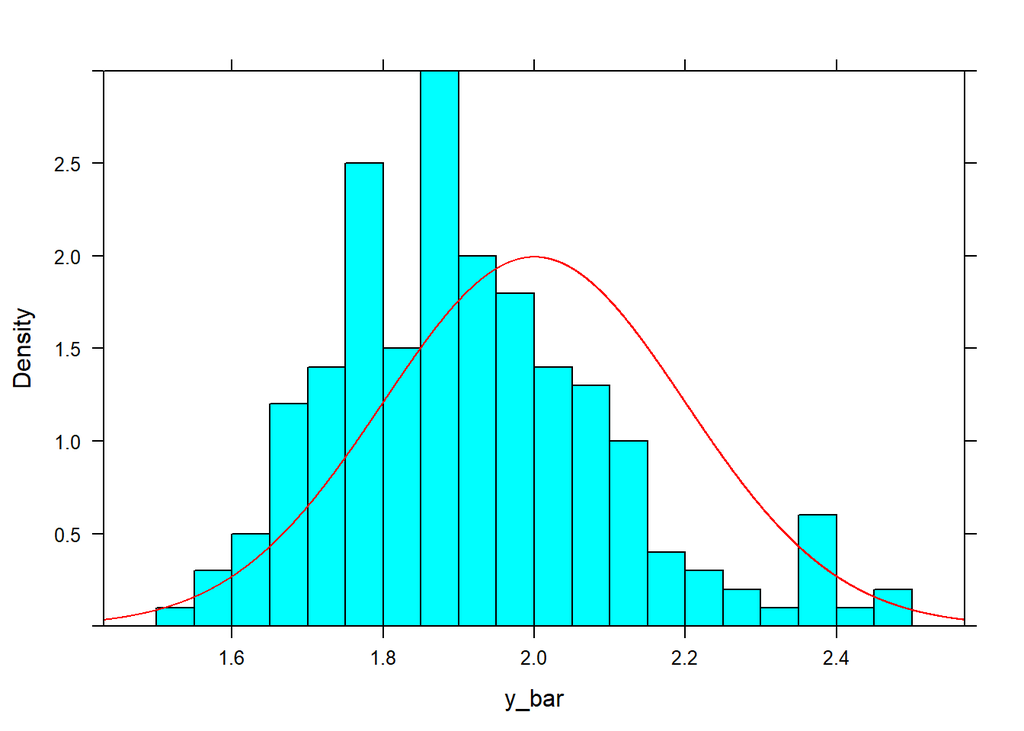

```r
histogram(y_bar, breaks = 15, type="density",ylim=c(0,3))
plotDist("norm", mean = 2, sd = 0.2, add = TRUE, col = "red", ylim=c(0,3))
```

- Make a boxplot of `y_bar` and explain how a boxplot is constructed.

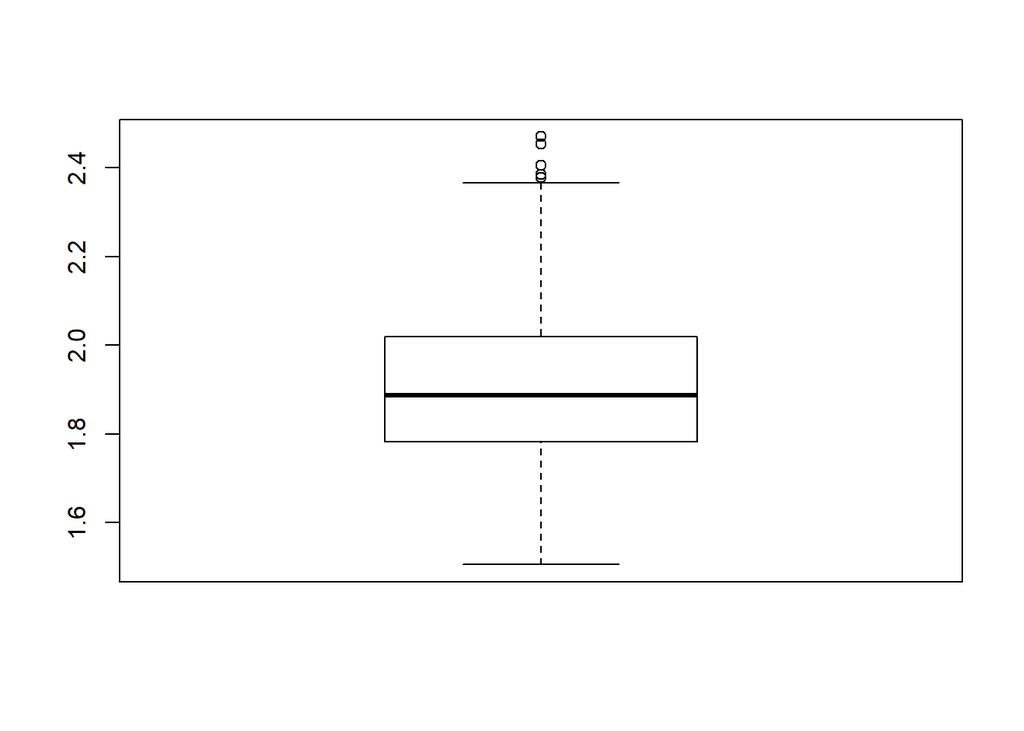

```r
boxplot(y_bar)
```

Finally, consider the theoretical boxplot of a general normal distribution with mean $\mu$ and standard deviation $\sigma$, and find the probability of being an outlier according to the 1.5$\cdot$IQR criterion:

- First find the $z$-score of the lower/upper quartile. I.e. the value of $z$ such that $\mu \pm z\sigma$ is the lower/upper quartile.

q1=$\mu + z*sigma$ q3=$\mu - z*sigma$

```r
q1 <- qdist("norm", 0.25, plot = FALSE)
q3 <-qdist("norm", 0.75, plot = FALSE)
q1
```

```
## [1] -0.6745
```

```r
q3
```

```
## [1] 0.6745
```

- Use this to find the IQR (expressed in terms of $\sigma$). The IQR then is $(\mu+0.6745\sigma)-(\mu-0.6745\sigma) = 2\cdot0.6745\sigma = 1.349\sigma$
- Now find the $z$-score of the maximal extent of the whisker. I.e. the value of $z$ such that $\mu \pm z\sigma$ is the endpoint of lower/upper whisker.

```r
Ll = -0.6745-1.5*1.349
Ul = 0.6745+1.5*1.349
Ll
```

```
## [1] -2.698
```

```r
Ul
```

```
## [1] 2.698
```

- Find the probability of being an outlier.

```r
PLl = pdist("norm", q = Ll, mean = 0, sd = 1, plot = FALSE)
PUl = pdist("norm", q = Ul, mean = 0, sd = 1, plot = FALSE)
PIN = PUl-PLl
POUT = 1-PIN
POUT
```

```
## [1] 0.006976
```